# HAPPEN study analysis v1.4

NW, BM

2026-02-19

# 1 Version details

Current version includes final data check for manuscript preparation.

This report summarises primary, secondary and tertiary outcomes from the HAPPEN trial. Analyses follow details outlined in the Statistical Analysis Plan (https://doi.org/10.1101/2025.08.14.25333719).

Relevant descriptions from the SAP are provided in subsequent sections.

# 2 Study design

The HAPPEN study design was a stepped-wedge cluster randomised trial across three public hospitals in Australia. The study design was defined by nine clusters, where a single ward was defined as a cluster. Three wards from each participating hospital were enrolled in the study. Wards within each hospital were randomised to one of three treatment sequences, which determined their transition from the control condition (current standard of oral care) to the intervention condition (oral care bundle). No transition phase was assumed between control and intervention conditions.

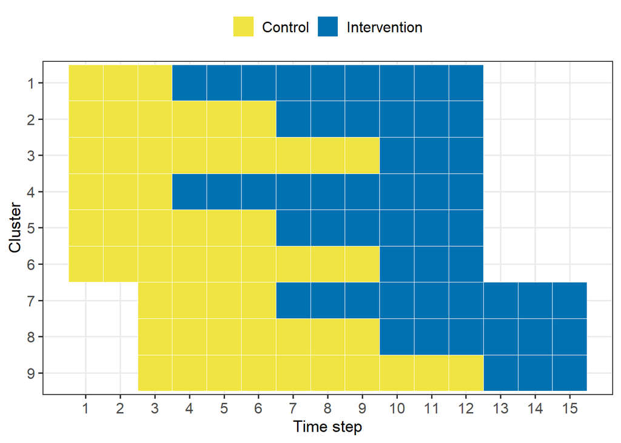

Figure 1: Observed treatment sequences

Observed treatment sequences match the planned design for Hospitals 1 and 2, starting in June 2024. Trial commencement was delayed in Hospital 3 was delayed by two months. The observed treatment sequences at Hospital 3 were therefore shifted to start in August 2024. All hospitals collected data for 12 months. The observed treatment sequences by cluster are in Figure 1.

# 3 Inclusion/exclusion criteria

Data were provided for 12,474 REDCap records. Initial data cleaning assessed records based on inclusion/exclusion criteria for study enrollment and timing of infections relative to study ward admission and discharge dates.

Additional record exclusions were based on the availability of a patient’s medical records at the time surveillance, missing ward admission and discharges dates need to define patient time at-risk, and time spent on a study ward. A summary of numbers excluded is provided below.

- Under 18 years of age: 12
- No medical record available at the time of surveillance (Other reasons): 29
- No hospital and ward identifiers: 15
- Duplicate records: 1
- Missing ward admission and/or discharge dates: 23
- Admitted to a study ward for less than 48 hours: 3336
- Discharged from a study ward before the start of the cluster control period: 188

The final sample size for analysis was 8,870.

# 4 Descriptive statistics

Cohort characteristics were summarised using descriptive statistics by study hospital (Hospital 1, Hospital 2, Hospital 2), study condition at the time of ward admission (Control, Intervention), primary outcome assessment (no HAP, HAP), and overall infection outcome based on assessment of HAP, lower-upper respiratory infections (LURI) and EENT-Oral (No infection, 1 or more infections).

For each cohort stratification in Tables 1 to 5, categorical variables are reported as total events/total records with corresponding percentages. Continuous variables are reported as quantiles, Median (Q1 to Q3), and means with standard deviations, Mean (SD). Total sample size per group are reported in each table.

Table 1: Cohort characteristics by study hospital

| Characteristic | All patients | Hospital 1 | Hospital 2 | Hospital 3 |
| --- | --- | --- | --- | --- |
| Total records | 8,870 | 3,499 | 2,976 | 2,395 |
| Gender: Female | 4,587/8,869 (51.7%) | 1,801/3,498 (51.5%) | 1,555/2,976 (52.3%) | 1,231/2,395 (51.4%) |
| Age, years | 76 (64 to 85) 72.5 (17) | 73 (61 to 81) 69.5 (16.1) | 82 (73 to 88) 78.9 (13.3) | 75 (58 to 85) 69.0 (20.0) |
| Days on study ward | 6 (4 to 11) 9.5 (12.5) | 6 (3 to 11) 9.9 (16.0) | 6 (4 to 11) 9.3 (8.8) | 6 (4 to 10) 9.2 (10.5) |
| Hospital length of stay, days | 7 (4 to 13) 11.2 (15.2) | 6 (4 to 12) 11.4 (18.2) | 9 (6 to 15) 12.4 (14.4) | 6 (4 to 11) 9.5 (10.5) |
| Reason for discharge from ward: Death | 446/8,870 (5.0%) | 119/3,499 (3.4%) | 262/2,976 (8.8%) | 65/2,395 (2.7%) |
| Reason for discharge from ward: Discharged to home/other facility | 6,032/8,870 (68.0%) | 1,583/3,499 (45.2%) | 2,205/2,976 (74.1%) | 2,244/2,395 (93.7%) |
| Reason for discharge from ward: Transferred | 2,392/8,870 (27.0%) | 1,797/3,499 (51.4%) | 509/2,976 (17.1%) | 86/2,395 (3.6%) |
| Receiving antimicrobial therapy excluding surgical prophylaxis: Yes | 5,647/8,870 (63.7%) | 2,266/3,499 (64.8%) | 2,036/2,976 (68.4%) | 1,345/2,395 (56.2%) |
| Documented fever: Yes | 1,379/8,870 (15.5%) | 616/3,499 (17.6%) | 268/2,976 (9.0%) | 495/2,395 (20.7%) |
| Proton pump inhibitor: Yes | 3,198/5,780 (55.3%) | 1,443/2,323 (62.1%) | 1,036/2,064 (50.2%) | 719/1,393 (51.6%) |
| History of stroke: Yes | 863/5,780 (14.9%) | 455/2,323 (19.6%) | 214/2,064 (10.4%) | 194/1,393 (13.9%) |
| History of dysphagia: Yes | 1,294/5,780 (22.4%) | 552/2,323 (23.8%) | 340/2,064 (16.5%) | 402/1,393 (28.9%) |
| History of dementia: Yes | 714/5,780 (12.4%) | 239/2,323 (10.3%) | 281/2,064 (13.6%) | 194/1,393 (13.9%) |

Table 2: Cohort characteristics by study condition

| Characteristic | All patients | Control | Intervention |
| --- | --- | --- | --- |
| Total records | 8,870 | 4,523 | 4,347 |
| Hospital: 1 | 3,499 | 1,815 | 1,684 |
| Hospital: 2 | 2,976 | 1,575 | 1,401 |
| Hospital: 3 | 2,395 | 1,133 | 1,262 |
| Gender: Female | 4,587/8,869 (51.7%) | 2,356/4,522 (52.1%) | 2,231/4,347 (51.3%) |
| Age, years | 76 (64 to 85) 72.5 (17) | 77 (63 to 85) 72.4 (17.4) | 76 (64 to 85) 72.7 (16.6) |
| Days on study ward | 6 (4 to 11) 9.5 (12.5) | 6 (4 to 12) 10.4 (15.1) | 6 (4 to 10) 8.6 (8.9) |
| Hospital length of stay, days | 7 (4 to 13) 11.2 (15.2) | 7 (5 to 14) 12.2 (18.0) | 7 (4 to 12) 10.2 (11.4) |
| Reason for discharge from ward: Death | 446/8,870 (5.0%) | 248/4,523 (5.5%) | 198/4,347 (4.6%) |
| Reason for discharge from ward: Discharged to home/other facility | 6,032/8,870 (68.0%) | 3,143/4,523 (69.5%) | 2,889/4,347 (66.5%) |
| Reason for discharge from ward: Transferred | 2,392/8,870 (27.0%) | 1,132/4,523 (25.0%) | 1,260/4,347 (29.0%) |
| Receiving antimicrobial therapy excluding surgical prophylaxis: Yes | 5,647/8,870 (63.7%) | 3,070/4,523 (67.9%) | 2,577/4,347 (59.3%) |
| Documented fever: Yes | 1,379/8,870 (15.5%) | 780/4,523 (17.2%) | 599/4,347 (13.8%) |
| Proton pump inhibitor: Yes | 3,198/5,780 (55.3%) | 1,761/3,137 (56.1%) | 1,437/2,643 (54.4%) |
| History of stroke: Yes | 863/5,780 (14.9%) | 430/3,137 (13.7%) | 433/2,643 (16.4%) |
| History of dysphagia: Yes | 1,294/5,780 (22.4%) | 709/3,137 (22.6%) | 585/2,643 (22.1%) |
| History of dementia: Yes | 714/5,780 (12.4%) | 429/3,137 (13.7%) | 285/2,643 (10.8%) |

Table 3: Cohort characteristics by HAP

| Characteristic | All patients | No HAP | HAP |
| --- | --- | --- | --- |
| Total records | 8,870 | 8,792 | 78 |
| Hospital: 1 | 3,499 | 3,468 | 31 |
| Hospital: 2 | 2,976 | 2,957 | 19 |
| Hospital: 3 | 2,395 | 2,367 | 28 |
| Gender: Female | 4,587/8,869 (51.7%) | 4,544/8,791 (51.7%) | 43/78 (55.1%) |
| Age, years | 76 (64 to 85) 72.5 (17) | 76 (64 to 85.0) 72.5 (17.1) | 78 (66 to 84.8) 74.7 (13.2) |
| Days on study ward | 6 (4 to 11) 9.5 (12.5) | 6 (4 to 11) 9.4 (12.4) | 20 (13 to 33) 24.5 (15.7) |
| Hospital length of stay, days | 7 (4 to 13) 11.2 (15.2) | 7 (4.0 to 13.0) 11.1 (15.1) | 22 (14.2 to 34.8) 26.7 (17.2) |
| Reason for discharge from ward: Death | 446/8,870 (5.0%) | 432/8,792 (4.9%) | 14/78 (17.9%) |
| Reason for discharge from ward: Discharged to home/other facility | 6,032/8,870 (68.0%) | 5,986/8,792 (68.1%) | 46/78 (59.0%) |
| Reason for discharge from ward: Transferred | 2,392/8,870 (27.0%) | 2,374/8,792 (27.0%) | 18/78 (23.1%) |
| Receiving antimicrobial therapy excluding surgical prophylaxis: Yes | 5,647/8,870 (63.7%) | 5,570/8,792 (63.4%) | 77/78 (98.7%) |
| Documented fever: Yes | 1,379/8,870 (15.5%) | 1,337/8,792 (15.2%) | 42/78 (53.8%) |
| Proton pump inhibitor: Yes | 3,198/5,780 (55.3%) | 3,138/5,702 (55.0%) | 60/78 (76.9%) |
| History of stroke: Yes | 863/5,780 (14.9%) | 846/5,702 (14.8%) | 17/78 (21.8%) |
| History of dysphagia: Yes | 1,294/5,780 (22.4%) | 1,263/5,702 (22.2%) | 31/78 (39.7%) |
| History of dementia: Yes | 714/5,780 (12.4%) | 701/5,702 (12.3%) | 13/78 (16.7%) |

Table 4: Cohort characteristics by treatment seuquence allocation

| Characteristic | All patients | Sequence 1 | Sequence 2 | Sequence 3 |
| --- | --- | --- | --- | --- |
| Total records | 8,870 | 3,029 | 3,367 | 2,474 |
| Gender: Female | 4,587/8,869 (51.7%) | 1,490/3,028 (49.2%) | 1,725/3,367 (51.2%) | 1,372/2,474 (55.5%) |
| Age, years | 76 (64 to 85) 72.5 (17) | 76 (64 to 84) 72.4 (16.5) | 77 (64 to 85) 72.8 (16.6) | 77 (63 to 86) 72.4 (18.2) |
| Days on study ward | 6 (4 to 11) 9.5 (12.5) | 6 (4 to 10) 9.0 (13.9) | 6 (4 to 11) 9.6 (12.2) | 7 (4 to 12) 10.0 (11.0) |
| Hospital length of stay, days | 7 (4 to 13) 11.2 (15.2) | 7 (4 to 12) 10.8 (15.0) | 7 (4 to 13) 11.3 (15.0) | 8 (5 to 14) 11.6 (15.7) |
| Reason for discharge from ward: Death | 446/8,870 (5.0%) | 58/3,029 (1.9%) | 255/3,367 (7.6%) | 133/2,474 (5.4%) |
| Reason for discharge from ward: Discharged to home/other facility | 6,032/8,870 (68.0%) | 2,062/3,029 (68.1%) | 2,139/3,367 (63.5%) | 1,831/2,474 (74.0%) |
| Reason for discharge from ward: Transferred | 2,392/8,870 (27.0%) | 909/3,029 (30.0%) | 973/3,367 (28.9%) | 510/2,474 (20.6%) |
| Receiving antimicrobial therapy excluding surgical prophylaxis: Yes | 5,647/8,870 (63.7%) | 1,530/3,029 (50.5%) | 2,341/3,367 (69.5%) | 1,776/2,474 (71.8%) |
| Documented fever: Yes | 1,379/8,870 (15.5%) | 366/3,029 (12.1%) | 581/3,367 (17.3%) | 432/2,474 (17.5%) |
| Proton pump inhibitor: Yes | 3,198/5,780 (55.3%) | 824/1,592 (51.8%) | 1,371/2,384 (57.5%) | 1,003/1,804 (55.6%) |
| History of stroke: Yes | 863/5,780 (14.9%) | 416/1,592 (26.1%) | 265/2,384 (11.1%) | 182/1,804 (10.1%) |
| History of dysphagia: Yes | 1,294/5,780 (22.4%) | 456/1,592 (28.6%) | 474/2,384 (19.9%) | 364/1,804 (20.2%) |
| History of dementia: Yes | 714/5,780 (12.4%) | 209/1,592 (13.1%) | 260/2,384 (10.9%) | 245/1,804 (13.6%) |

Table 5: Cohort characteristics by infection outcome

| Characteristic | All patients | No infection | Infection |
| --- | --- | --- | --- |
| Total records | 8,870 | 8,543 | 327 |
| Hospital: 1 | 3,499 | 3,347 | 152 |
| Hospital: 2 | 2,976 | 2,845 | 131 |
| Hospital: 3 | 2,395 | 2,351 | 44 |
| Gender: Female | 4,587/8,869 (51.7%) | 4,421/8,542 (51.8%) | 166/327 (50.8%) |
| Age, years | 76 (64 to 85) 72.5 (17) | 76 (64.0 to 85) 72.4 (17.1) | 79 (67.5 to 85) 75.5 (13.5) |
| Days on study ward | 6 (4 to 11) 9.5 (12.5) | 6 (4 to 10) 9.1 (11.7) | 17 (10 to 28) 21.5 (22.8) |
| Hospital length of stay, days | 7 (4 to 13) 11.2 (15.2) | 7 (4 to 12) 10.8 (14.6) | 18 (11 to 30) 23.6 (23.6) |
| Reason for discharge from ward: Death | 446/8,870 (5.0%) | 396/8,543 (4.6%) | 50/327 (15.3%) |
| Reason for discharge from ward: Discharged to home/other facility | 6,032/8,870 (68.0%) | 5,858/8,543 (68.6%) | 174/327 (53.2%) |
| Reason for discharge from ward: Transferred | 2,392/8,870 (27.0%) | 2,289/8,543 (26.8%) | 103/327 (31.5%) |
| Receiving antimicrobial therapy excluding surgical prophylaxis: Yes | 5,647/8,870 (63.7%) | 5,324/8,543 (62.3%) | 323/327 (98.8%) |
| Documented fever: Yes | 1,379/8,870 (15.5%) | 1,265/8,543 (14.8%) | 114/327 (34.9%) |
| Proton pump inhibitor: Yes | 3,198/5,780 (55.3%) | 2,973/5,453 (54.5%) | 225/327 (68.8%) |
| History of stroke: Yes | 863/5,780 (14.9%) | 794/5,453 (14.6%) | 69/327 (21.1%) |
| History of dysphagia: Yes | 1,294/5,780 (22.4%) | 1,167/5,453 (21.4%) | 127/327 (38.8%) |
| History of dementia: Yes | 714/5,780 (12.4%) | 665/5,453 (12.2%) | 49/327 (15.0%) |

# 5 Time at-risk

Table 6: Summary of admissions in terms of total study months spent on a study ward

| Number of study months on study ward | n | % Total records |
| --- | --- | --- |
| 1 | 6,158 | 69.4 |
| 2 | 2,573 | 29.0 |
| 3 | 112 | 1.3 |
| 4 | 19 | 0.2 |
| 5 | 4 | 0.0 |
| 6 | 2 | 0.0 |
| 8 | 1 | 0.0 |
| 10 | 1 | 0.0 |

Table 7: Summary of admissions in terms of total study periods spent on a study ward

| Number of study periods on study ward (1 study period = 3 months) | n | % Total records |
| --- | --- | --- |
| 1 | 8,003 | 90.2 |
| 2 | 864 | 9.7 |
| 3 | 1 | 0.0 |
| 4 | 2 | 0.0 |

As an indication of available sample size per cluster-month, 2 shows the total number of records included in analysis by cluster and study month.

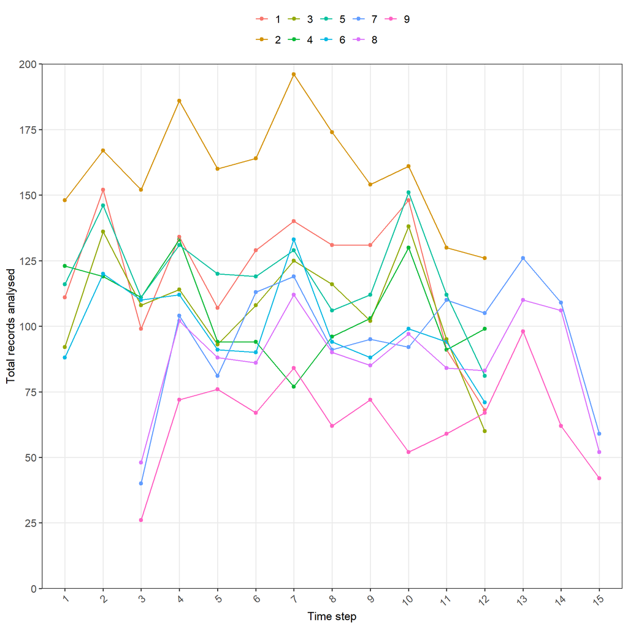

Figure 2: Total records analysed by cluster and time step

# 6 Observed infections

Table 8 show the total number of infections reported by cluster and study condition. The total number of infections as the percentage of admitted patients is also provided.

Table 8: Total infections reported by cluster and study condition

| Hospital | Ward | cluster | Control | Intervention |
| --- | --- | --- | --- | --- |
| **HAP** |  |  |  |  |
| 1 | 1 | 1 | 1/255 (0.39%) | 7/808 (0.87%) |
| 1 | 2 | 2 | 3/741 (0.4%) | 2/736 (0.27%) |
| 1 | 3 | 3 | 15/725 (2.1%) | 3/234 (1.3%) |
| 2 | 1 | 4 | 1/282 (0.35%) | 1/757 (0.13%) |
| 2 | 2 | 5 | 5/525 (0.95%) | 5/518 (0.97%) |
| 2 | 3 | 6 | 6/688 (0.87%) | 1/206 (0.49%) |
| 3 | 1 | 7 | 2/222 (0.9%) | 7/705 (0.99%) |
| 3 | 2 | 8 | 6/409 (1.5%) | 3/438 (0.68%) |
| 3 | 3 | 9 | 7/441 (1.6%) | 3/180 (1.7%) |
| **Lower/Upper respiratory** |  |  |  |  |
| 1 | 1 | 1 | 1/255 (0.39%) | 5/808 (0.62%) |
| 1 | 2 | 2 | 2/741 (0.27%) | 1/736 (0.14%) |
| 1 | 3 | 3 | 5/725 (0.69%) | 1/234 (0.43%) |
| 2 | 1 | 4 | 0/282 (0%) | 1/757 (0.13%) |
| 2 | 2 | 5 | 2/525 (0.38%) | 4/518 (0.77%) |
| 2 | 3 | 6 | 3/688 (0.44%) | 0/206 (0%) |
| 3 | 1 | 7 | 3/222 (1.4%) | 5/705 (0.71%) |
| 3 | 2 | 8 | 0/409 (0%) | 3/438 (0.68%) |
| 3 | 3 | 9 | 2/441 (0.45%) | 1/180 (0.56%) |
| **EENT-Oral** |  |  |  |  |
| 1 | 1 | 1 | 2/255 (0.78%) | 18/808 (2.2%) |
| 1 | 2 | 2 | 25/741 (3.4%) | 20/736 (2.7%) |
| 1 | 3 | 3 | 47/725 (6.5%) | 8/234 (3.4%) |
| 2 | 1 | 4 | 7/282 (2.5%) | 16/757 (2.1%) |
| 2 | 2 | 5 | 27/525 (5.1%) | 32/518 (6.2%) |
| 2 | 3 | 6 | 17/688 (2.5%) | 6/206 (2.9%) |
| 3 | 1 | 7 | 0/222 (0%) | 1/705 (0.14%) |
| 3 | 2 | 8 | 2/409 (0.49%) | 0/438 (0%) |
| 3 | 3 | 9 | 0/441 (0%) | 0/180 (0%) |

The next table shows overall observed infections by control and intervention.

Table 9: Total infections reported by study condition

| Infection | All patients | Control | Intervention |
| --- | --- | --- | --- |
| NV-HAP | 78 (0.879%) | 46 (1.073%) | 32 (0.698%) |
| Lower/Upper respiratory | 39 (0.44%) | 18 (0.42%) | 21 (0.458%) |
| EENT-Oral | 228 (2.57%) | 127 (2.962%) | 101 (2.204%) |

To account for time at-risk, Table 10 shows the reported number of infections per 100 patient days at-risk.

Note: days at-risk is defined as the number of days from ward admission to infection or discharge for non-infected patients

Table 10: Total infections per 100 at-risk admission days reported by cluster and study condition. The total number of at-risk patient days is defined at the number of days until infection or discharge if not infected

| Hospital | Ward | cluster | Control | Intervention |
| --- | --- | --- | --- | --- |
| **HAP** |  |  |  |  |
| 1 | 1 | 1 | 3,727; 0.08 | 10,182; 0.05 |
| 1 | 2 | 2 | 8,636; 0.03 | 8,181; 0.02 |
| 1 | 3 | 3 | 9,593; 0.16 | 2,809; 0.11 |
| 2 | 1 | 4 | 2,816; 0.04 | 7,113; 0.01 |
| 2 | 2 | 5 | 7,400; 0.08 | 6,632; 0.06 |
| 2 | 3 | 6 | 8,862; 0.08 | 2,693; 0 |
| 3 | 1 | 7 | 2,651; 0.11 | 8,282; 0.07 |
| 3 | 2 | 8 | 4,702; 0.13 | 5,196; 0.06 |
| 3 | 3 | 9 | 5,128; 0.16 | 1,882; 0.11 |
| **Lower/Upper respiratory** |  |  |  |  |
| 1 | 1 | 1 | 3,697; 0.05 | 10,189; 0.04 |
| 1 | 2 | 2 | 8,606; 0.02 | 8,202; 0.01 |
| 1 | 3 | 3 | 9,799; 0.05 | 2,871; 0.03 |
| 2 | 1 | 4 | 2,822; 0 | 7,107; 0.01 |
| 2 | 2 | 5 | 7,440; 0.03 | 6,684; 0.06 |
| 2 | 3 | 6 | 9,004; 0.03 | 2,702; 0 |
| 3 | 1 | 7 | 2,604; 0.15 | 8,348; 0.05 |
| 3 | 2 | 8 | 4,773; 0 | 5,258; 0.06 |
| 3 | 3 | 9 | 5,213; 0.04 | 1,909; 0.05 |
| **EENT-Oral** |  |  |  |  |
| 1 | 1 | 1 | 3,702; 0.14 | 10,018; 0.15 |
| 1 | 2 | 2 | 8,440; 0.31 | 7,995; 0.24 |
| 1 | 3 | 3 | 9,301; 0.52 | 2,788; 0.25 |
| 2 | 1 | 4 | 2,766; 0.29 | 6,994; 0.21 |
| 2 | 2 | 5 | 7,109; 0.41 | 6,253; 0.48 |
| 2 | 3 | 6 | 8,776; 0.19 | 2,623; 0.23 |
| 3 | 1 | 7 | 2,664; 0 | 8,393; 0.01 |
| 3 | 2 | 8 | 4,761; 0.04 | 5,290; 0 |
| 3 | 3 | 9 | 5,231; 0 | 1,919; 0 |

To assess for general time trends in infection outcomes, Figures 3 and 4 display the observed percentages by cluster and infection type over time.

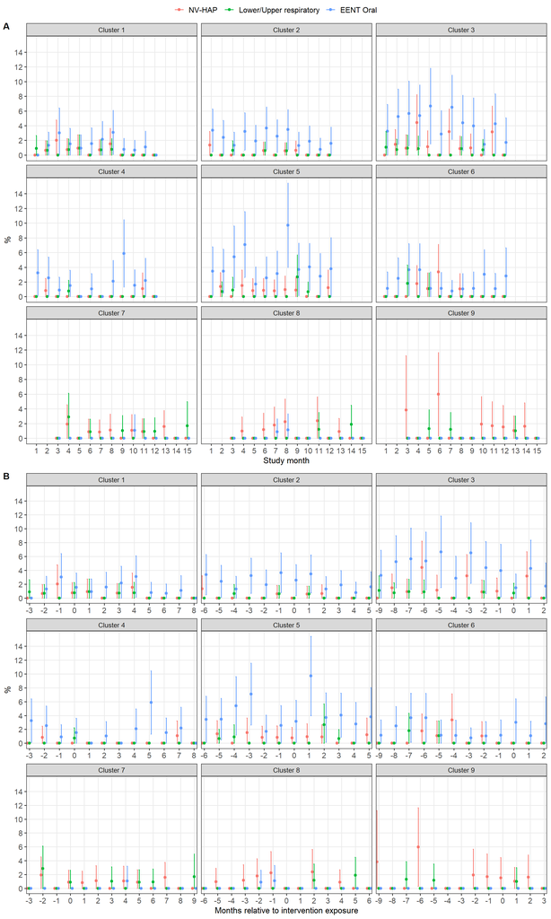

Figure 3: Unadjusted % of patients with reported infection by cluster and: monthly time step (A), months relative to intervention exposure (B)

Figure 4 shows the same data but by treatment sequence instead of cluster.

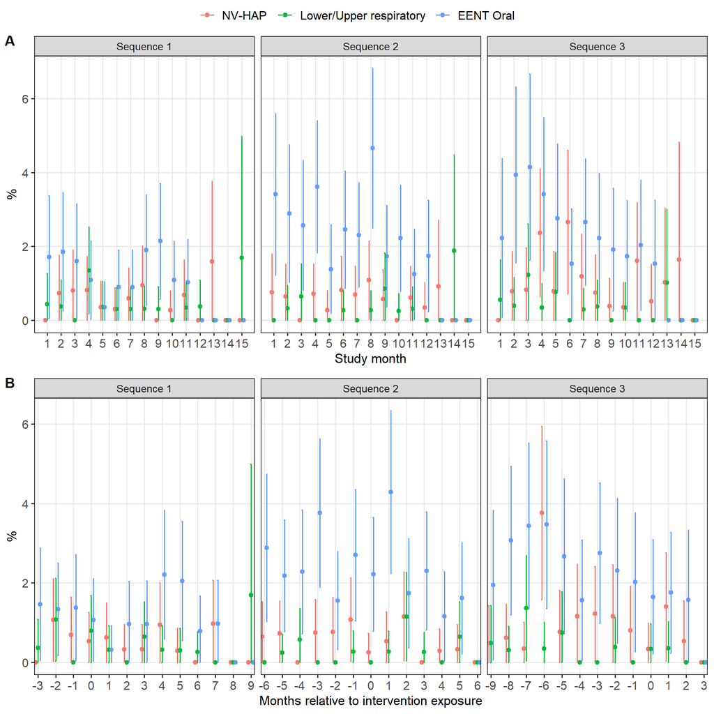

Figure 4: Unadjusted % of patients with reported infection by treatment sequence and: monthly time step (A), months relative to intervention exposure (B)

Figures 5presents unadjusted incidence rates per 100 at risk patient-days in the same format as above.

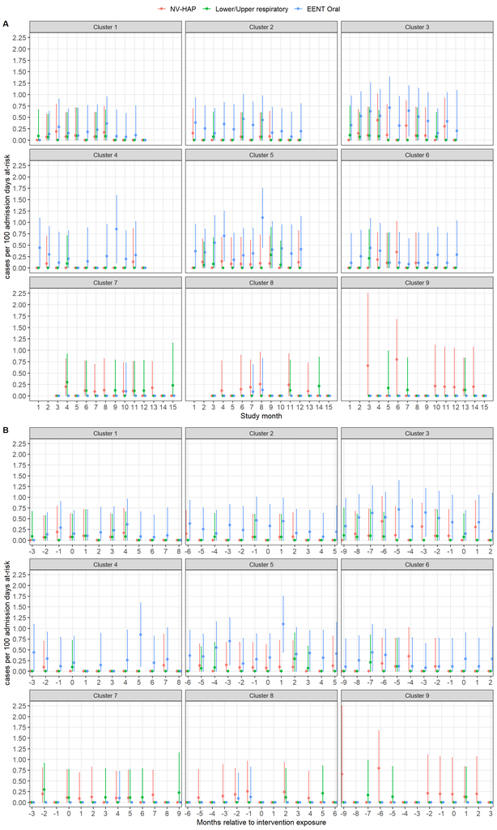

Figure 5: Unadjusted incidence rates per 100 at risk days by cluster and: monthly time step (A), months relative to intervention exposure (B)

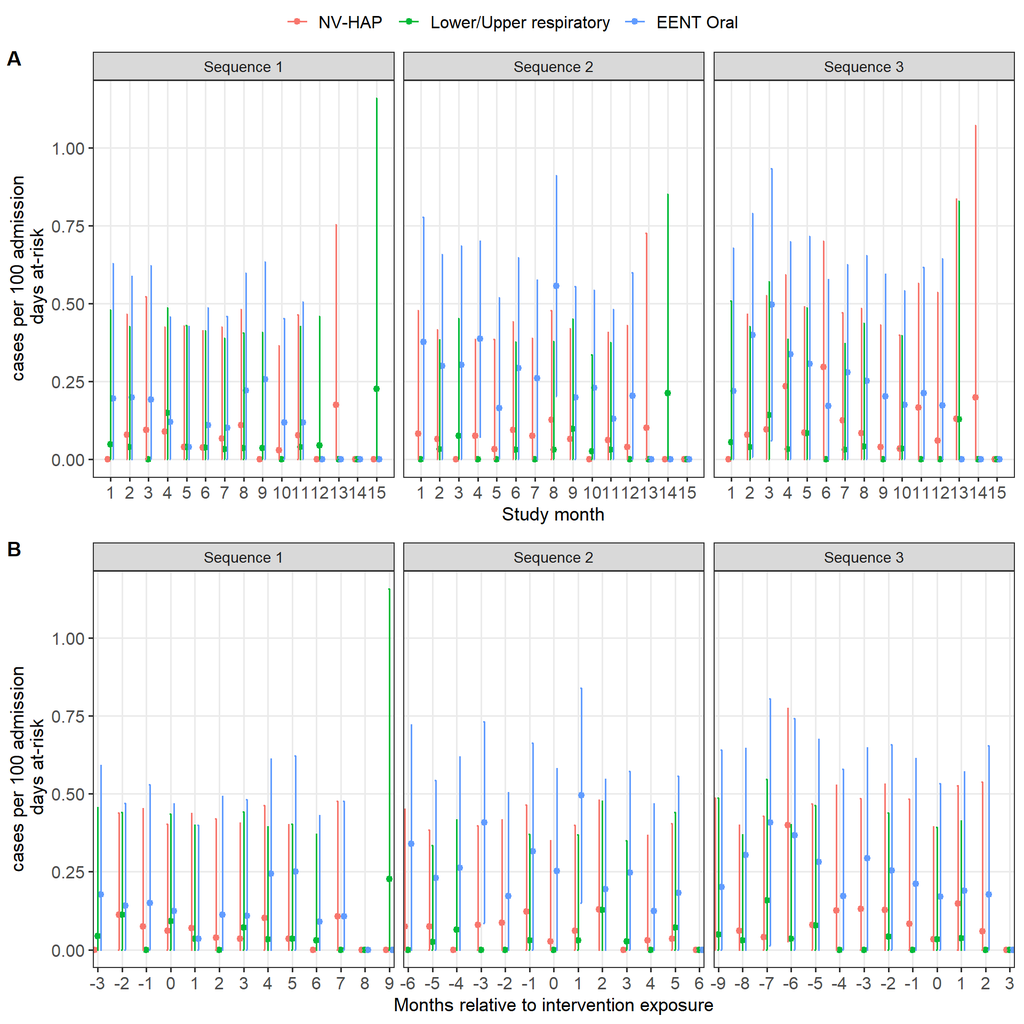

Figure 6: Unadjusted incidence rates per 100 at risk days by treatment sequence and: monthly time step (A), months relative to intervention exposure (B)

At the patient level, Figures 7 to 9 show unadjusted cumulative incidence functions for each infection type by study condition. For each figure, cumulative incidence functions are displayed for all observed lengths of ward stay (left panel), and lengths of stay up to 30 days (right panel).

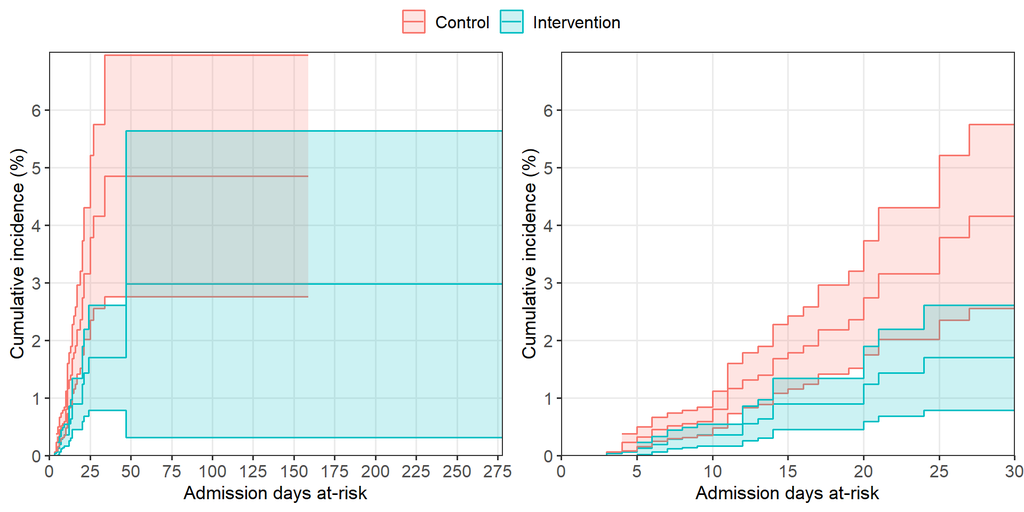

Figure 7: Cumulative incidence of HAP infection by study condition

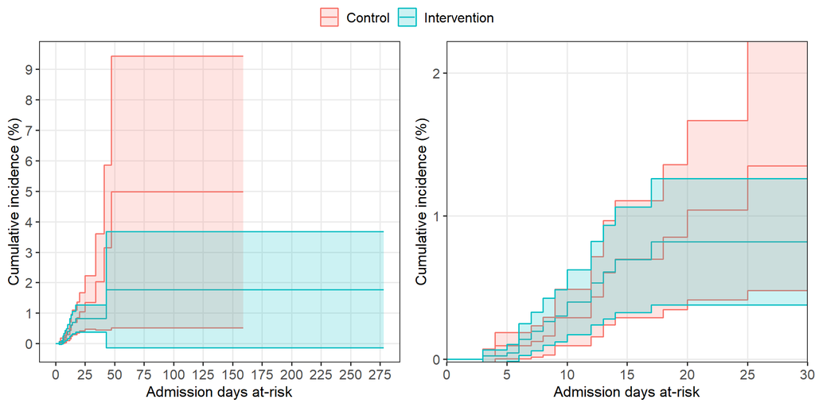

Figure 8: Cumulative incidence of lower/upper respiratory infection by study condition

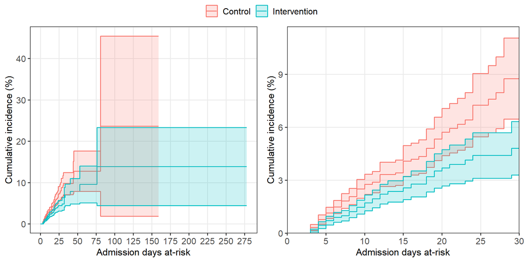

Figure 9: Cumulative incidence of EENT-Oral infection by study condition

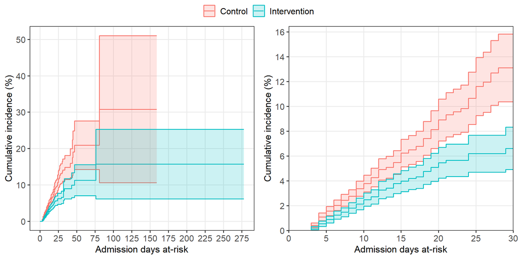

Figure 10: Cumulative proportion of HAP/LURI/EENT-Oral - time to first infection

# 7 Primary outcome analysis

The primary outcome is non-ventilator-associated hospital-acquired pneumonia (HAP). The primary outcome definition is the European Centre for Disease Control definition of HAP.

The primary outcome was analysed at the patient-level and the cluster level. Patient-level analysis modelled the incidence of HAP adjusted for ward days at-risk. The final ward day at-risk was defined as the date of infection onset (HAP) or the date of ward discharge (no HAP).

Cluster-level analysis modelling the number of new HAP events per 100 at-risk admissions, defined as total admissions and admission days at-risk. Model estimates are reported as incidence risk ratios with 95% confidence intervals and p-values.

The main analysis included all study wards. Sensitivity analysis applied a leave-one-cluster-out analysis to assess the sensitivity of estimated intervention effectiveness.

## 7.1 Patient-level analysis

Table 11 summarises main and sensitivity analysis results for HAP risk at the patient-level. Model estimates are reported as hazard ratios with 95% confidence intervals and p-values.

Results are presented as hazard ratios with 95% confidence intervals for the main analysis where all clusters are included, and for leave-one-cluster-out sensitivity analysis.

Quantities ending in _c correspond to results following post-correction for the number of clusters. (Degree of freedom correction, t distribution with total included clusters - 1 d.f.)

Table 11: Estimated intervention effectiveness on the incidence of HAP; patient-level analysis

| Cluster excluded | Hazard ratio | 95% CI | p.value | 95% CI_c | p.value_c |
| --- | --- | --- | --- | --- | --- |
| **Main analysis** |  |  |  |  |  |
| None | 0.396 | 0.192 - 0.817 | 0.012 | 0.165 - 0.949 | 0.041 |
| **Sensitivity analysis** |  |  |  |  |  |
| None - random intervention effect per hospital | 0.396 | 0.192 - 0.818 | 0.012 | 0.165 - 0.95 | 0.041 |
| 1 | 0.355 | 0.145 - 0.868 | 0.023 | 0.116 - 1.08 | 0.064 |
| 2 | 0.340 | 0.172 - 0.672 | 0.002 | 0.146 - 0.796 | 0.021 |
| 3 | 0.405 | 0.192 - 0.854 | 0.018 | 0.16 - 1.03 | 0.055 |
| 4 | 0.487 | 0.228 - 1.04 | 0.063 | 0.189 - 1.25 | 0.112 |
| 5 | 0.349 | 0.157 - 0.776 | 0.010 | 0.128 - 0.946 | 0.042 |
| 6 | 0.368 | 0.167 - 0.807 | 0.013 | 0.138 - 0.982 | 0.047 |
| 7 | 0.380 | 0.17 - 0.848 | 0.018 | 0.139 - 1.03 | 0.056 |
| 8 | 0.430 | 0.195 - 0.948 | 0.036 | 0.16 - 1.15 | 0.081 |
| 9 | 0.436 | 0.199 - 0.954 | 0.038 | 0.164 - 1.16 | 0.083 |

## 7.2 Cluster-level analysis

Table 12 shows results of modelling the total number HAPs acquired per 100 ward admissions. For this analysis, patients are included in monthly denominators if they spent at least 1 day on the ward for a given month. Therefore, this analysis does not account for time spent on the ward.

Table 12: Estimated intervention effectiveness on the incidence of HAP; cluster-level analysis per 100 admissions

| Cluster excluded | Incidence rate ratio | 95% CI | p.value | 95% CI_c | p.value_c |
| --- | --- | --- | --- | --- | --- |
| **Main analysis** |  |  |  |  |  |
| None | 0.407 | 0.197 - 0.841 | 0.015 | 0.17 - 0.976 | 0.046 |
| **Sensitivity analysis** |  |  |  |  |  |
| None - random intervention effect per hospital | 0.407 | 0.197 - 0.841 | 0.015 | 0.17 - 0.976 | 0.046 |
| 1 | 0.293 | 0.131 - 0.657 | 0.003 | 0.107 - 0.803 | 0.025 |
| 2 | 0.313 | 0.159 - 0.619 | 0.001 | 0.134 - 0.733 | 0.016 |
| 3 | 0.360 | 0.166 - 0.777 | 0.009 | 0.137 - 0.942 | 0.041 |
| 4 | 0.407 | 0.196 - 0.847 | 0.016 | 0.163 - 1.02 | 0.053 |
| 5 | 0.327 | 0.15 - 0.712 | 0.005 | 0.124 - 0.864 | 0.030 |
| 6 | 0.356 | 0.162 - 0.779 | 0.010 | 0.134 - 0.946 | 0.042 |
| 7 | 0.338 | 0.154 - 0.742 | 0.007 | 0.126 - 0.902 | 0.035 |
| 8 | 0.378 | 0.171 - 0.835 | 0.016 | 0.14 - 1.02 | 0.053 |
| 9 | 0.332 | 0.147 - 0.751 | 0.008 | 0.12 - 0.92 | 0.038 |

Table 13 shows results of modelling the total number HAPs acquired per 100 at-risk admission days. For this analysis, total person-time per month divided by 100 was included as a model offset.

Table 13: Estimated intervention effectiveness on the incidence of HAP; cluster-level analysis per 100 at-risk admission days

| Cluster excluded | Incidence rate ratio | 95% CI | p.value | 95% CI_c | p.value_c |
| --- | --- | --- | --- | --- | --- |
| **Main analysis** |  |  |  |  |  |
| None | 0.409 | 0.198 - 0.845 | 0.016 | 0.171 - 0.981 | 0.046 |
| **Sensitivity analysis** |  |  |  |  |  |
| None - random intervention effect per hospital | 0.409 | 0.198 - 0.845 | 0.016 | 0.171 - 0.981 | 0.046 |
| 1 | 0.292 | 0.13 - 0.654 | 0.003 | 0.107 - 0.799 | 0.024 |
| 2 | 0.313 | 0.161 - 0.606 | 0.001 | 0.137 - 0.714 | 0.014 |
| 3 | 0.356 | 0.164 - 0.773 | 0.009 | 0.135 - 0.937 | 0.040 |
| 4 | 0.398 | 0.19 - 0.836 | 0.015 | 0.158 - 1 | 0.051 |
| 5 | 0.326 | 0.15 - 0.709 | 0.005 | 0.123 - 0.861 | 0.030 |
| 6 | 0.341 | 0.155 - 0.749 | 0.007 | 0.127 - 0.912 | 0.037 |
| 7 | 0.328 | 0.15 - 0.721 | 0.005 | 0.123 - 0.876 | 0.032 |
| 8 | 0.376 | 0.17 - 0.832 | 0.016 | 0.139 - 1.01 | 0.052 |
| 9 | 0.334 | 0.148 - 0.752 | 0.008 | 0.121 - 0.92 | 0.038 |

For cluster-level analysis, the predicted number of infections during control and intervention conditions is given in 14. Results are reported as point estimates with 95% confidence intervals.

| Cluster-level analysis | Control | Intervention |
| --- | --- | --- |
| per 100 admissions | 1; 0.54 - 1.5 | 0.41; 0.21 - 0.61 |
| per 100 at-risk admission days | 1; 0.55 - 1.5 | 0.41; 0.21 - 0.6 |

# 8 Secondary outcome analysis

Secondary outcomes were respiratory tract (lower and upper combined) and EENT-O infections. Analysis followed the same process as per the primary outcome.

## 8.1 Lower and upper respiratory infections

Patient-level analysis results are shown in Table 15. Cluster-level analysis results are shown in Table 16 and Table 17.

Table 15: Estimated intervention effectiveness on the incidence of LURI; patient-level analysis

| Cluster excluded | Hazard ratio | 95% CI | p.value | 95% CI_c | p.value_c |
| --- | --- | --- | --- | --- | --- |
| **Main analysis** |  |  |  |  |  |
| None | 1.64 | 0.613 - 4.39 | 0.325 | 0.5 - 5.38 | 0.358 |
| **Sensitivity analysis** |  |  |  |  |  |
| None - random intervention effect per hospital | 1.64 | 0.613 - 4.39 | 0.325 | 0.5 - 5.38 | 0.358 |
| 1 | 1.76 | 0.513 - 6.04 | 0.369 | 0.378 - 8.2 | 0.403 |
| 2 | 1.63 | 0.638 - 4.16 | 0.308 | 0.505 - 5.26 | 0.347 |
| 3 | 1.67 | 0.606 - 4.62 | 0.320 | 0.471 - 5.95 | 0.358 |
| 4 | 1.89 | 0.704 - 5.08 | 0.207 | 0.55 - 6.49 | 0.253 |
| 5 | 1.27 | 0.457 - 3.53 | 0.647 | 0.354 - 4.55 | 0.664 |
| 6 | 1.44 | 0.522 - 3.97 | 0.481 | 0.406 - 5.11 | 0.507 |
| 7 | 2.32 | 0.79 - 6.84 | 0.125 | 0.604 - 8.94 | 0.176 |
| 8 | 1.46 | 0.529 - 4.03 | 0.465 | 0.411 - 5.19 | 0.492 |
| 9 | 1.87 | 0.638 - 5.49 | 0.253 | 0.489 - 7.18 | 0.297 |

Table 16: Estimated intervention effectiveness on the incidence of LURI; cluster-level analysis per 100 admissions

| Cluster excluded | Incidence rate ratio | 95% CI | p.value | 95% CI_c | p.value_c |
| --- | --- | --- | --- | --- | --- |
| **Main analysis** |  |  |  |  |  |
| None | 1.60 | 0.589 - 4.32 | 0.357 | 0.48 - 5.31 | 0.388 |
| **Sensitivity analysis** |  |  |  |  |  |
| None - random intervention effect per hospital | 1.60 | 0.589 - 4.32 | 0.357 | 0.48 - 5.31 | 0.388 |
| 1 | 1.54 | 0.462 - 5.11 | 0.484 | 0.343 - 6.89 | 0.510 |
| 2 | 1.55 | 0.611 - 3.96 | 0.354 | 0.485 - 4.99 | 0.390 |
| 3 | 1.63 | 0.579 - 4.58 | 0.355 | 0.448 - 5.92 | 0.391 |
| 4 | 1.88 | 0.695 - 5.11 | 0.213 | 0.542 - 6.55 | 0.260 |
| 5 | 1.22 | 0.437 - 3.4 | 0.706 | 0.339 - 4.38 | 0.719 |
| 6 | 1.42 | 0.508 - 3.94 | 0.506 | 0.394 - 5.08 | 0.531 |
| 7 | 2.22 | 0.695 - 7.12 | 0.178 | 0.52 - 9.51 | 0.227 |
| 8 | 1.38 | 0.502 - 3.82 | 0.530 | 0.39 - 4.92 | 0.553 |
| 9 | 1.78 | 0.602 - 5.27 | 0.297 | 0.459 - 6.91 | 0.337 |

| Cluster excluded | Incidence rate ratio | 95% CI | p.value | 95% CI_c | p.value_c |
| --- | --- | --- | --- | --- | --- |
| **Main analysis** |  |  |  |  |  |
| None | 1.63 | 0.638 - 4.19 | 0.306 | 0.526 - 5.08 | 0.340 |
| **Sensitivity analysis** |  |  |  |  |  |
| None - random intervention effect per hospital | 1.63 | 0.638 - 4.19 | 0.306 | 0.526 - 5.08 | 0.340 |
| 1 | 1.68 | 0.499 - 5.68 | 0.401 | 0.369 - 7.69 | 0.433 |
| 2 | 1.66 | 0.649 - 4.26 | 0.289 | 0.514 - 5.38 | 0.330 |
| 3 | 1.70 | 0.619 - 4.66 | 0.304 | 0.482 - 5.99 | 0.343 |
| 4 | 1.94 | 0.714 - 5.25 | 0.194 | 0.557 - 6.73 | 0.242 |
| 5 | 1.29 | 0.468 - 3.53 | 0.626 | 0.364 - 4.53 | 0.643 |
| 6 | 1.44 | 0.535 - 3.87 | 0.471 | 0.419 - 4.94 | 0.498 |
| 7 | 2.34 | 0.793 - 6.91 | 0.124 | 0.606 - 9.05 | 0.175 |
| 8 | 1.46 | 0.534 - 3.98 | 0.462 | 0.416 - 5.11 | 0.490 |
| 9 | 1.87 | 0.641 - 5.45 | 0.252 | 0.491 - 7.11 | 0.296 |

## 8.2 EENT-Oral

Patient-level analysis results are shown in Table 18. Cluster-level analysis results are shown in Table 19 and Table 20.

Table 18: Estimated intervention effectiveness on the incidence of EENT-Oral; patient-level analysis

| Cluster excluded | Hazard ratio | 95% CI | p.value | 95% CI_c | p.value_c |
| --- | --- | --- | --- | --- | --- |
| **Main analysis** |  |  |  |  |  |
| None | 1.080 | 0.662 - 1.77 | 0.748 | 0.598 - 1.96 | 0.757 |
| **Sensitivity analysis** |  |  |  |  |  |
| None - random intervention effect per hospital | 1.080 | 0.652 - 1.8 | 0.757 | 0.587 - 2 | 0.766 |
| 1 | 1.060 | 0.619 - 1.82 | 0.829 | 0.541 - 2.08 | 0.836 |
| 2 | 1.160 | 0.679 - 1.99 | 0.584 | 0.594 - 2.27 | 0.604 |
| 3 | 1.190 | 0.644 - 2.21 | 0.573 | 0.553 - 2.58 | 0.593 |
| 4 | 1.220 | 0.708 - 2.11 | 0.469 | 0.618 - 2.42 | 0.496 |
| 5 | 1.030 | 0.588 - 1.79 | 0.928 | 0.512 - 2.06 | 0.931 |
| 6 | 0.884 | 0.522 - 1.5 | 0.648 | 0.458 - 1.71 | 0.664 |
| 7 | 1.130 | 0.688 - 1.84 | 0.637 | 0.609 - 2.08 | 0.654 |
| 8 | 1.120 | 0.684 - 1.84 | 0.648 | 0.605 - 2.08 | 0.664 |
| 9 | 1.040 | 0.638 - 1.7 | 0.868 | 0.565 - 1.92 | 0.873 |

Table 19: Estimated intervention effectiveness on the incidence of EENT-Oral; cluster-level analysis per 100 admissions

| Cluster excluded | Incidence rate ratio | 95% CI | p.value | 95% CI_c | p.value_c |
| --- | --- | --- | --- | --- | --- |
| **Main analysis** |  |  |  |  |  |
| None | 1.030 | 0.629 - 1.69 | 0.908 | 0.568 - 1.87 | 0.911 |
| **Sensitivity analysis** |  |  |  |  |  |
| None - random intervention effect per hospital | 1.030 | 0.629 - 1.69 | 0.908 | 0.568 - 1.87 | 0.911 |
| 1 | 0.992 | 0.58 - 1.7 | 0.977 | 0.507 - 1.94 | 0.978 |
| 2 | 1.140 | 0.667 - 1.96 | 0.624 | 0.584 - 2.24 | 0.642 |
| 3 | 1.120 | 0.6 - 2.07 | 0.730 | 0.515 - 2.42 | 0.742 |
| 4 | 1.180 | 0.684 - 2.05 | 0.546 | 0.597 - 2.35 | 0.568 |
| 5 | 0.965 | 0.554 - 1.68 | 0.901 | 0.483 - 1.93 | 0.905 |
| 6 | 0.848 | 0.501 - 1.44 | 0.539 | 0.439 - 1.64 | 0.562 |
| 7 | 1.070 | 0.653 - 1.75 | 0.791 | 0.578 - 1.98 | 0.800 |
| 8 | 1.080 | 0.657 - 1.77 | 0.764 | 0.581 - 2 | 0.775 |
| 9 | 0.997 | 0.61 - 1.63 | 0.991 | 0.54 - 1.84 | 0.991 |

Table 20: Estimated intervention effectiveness on the incidence of EENT-Oral; cluster-level analysis per 100 at-risk admission days

[output not shown]

# 9 Tertiary outcome analysis

For total infections, patient-level and cluster-level analysis results are shown in Table 21.

Table 21: Estimated intervention effectiveness for one or more infections during trial ward admission

| Analysis | OR (patient-level)/IRR (cluster-level) | 95% CI | p.value | 95% CI_c | p.value_c |
| --- | --- | --- | --- | --- | --- |
| Patient-level: 1+ infections during admission | 0.919 | 0.614 - 1.37 | 0.680 | 0.565 - 1.49 | 0.692 |
| Cluster-level: infections per 100 admissions | 0.916 | 0.62 - 1.35 | 0.658 | 0.572 - 1.47 | 0.672 |

Figure 11 summarises the monthly audit results on oral care, as a measure of intervention fidelity.

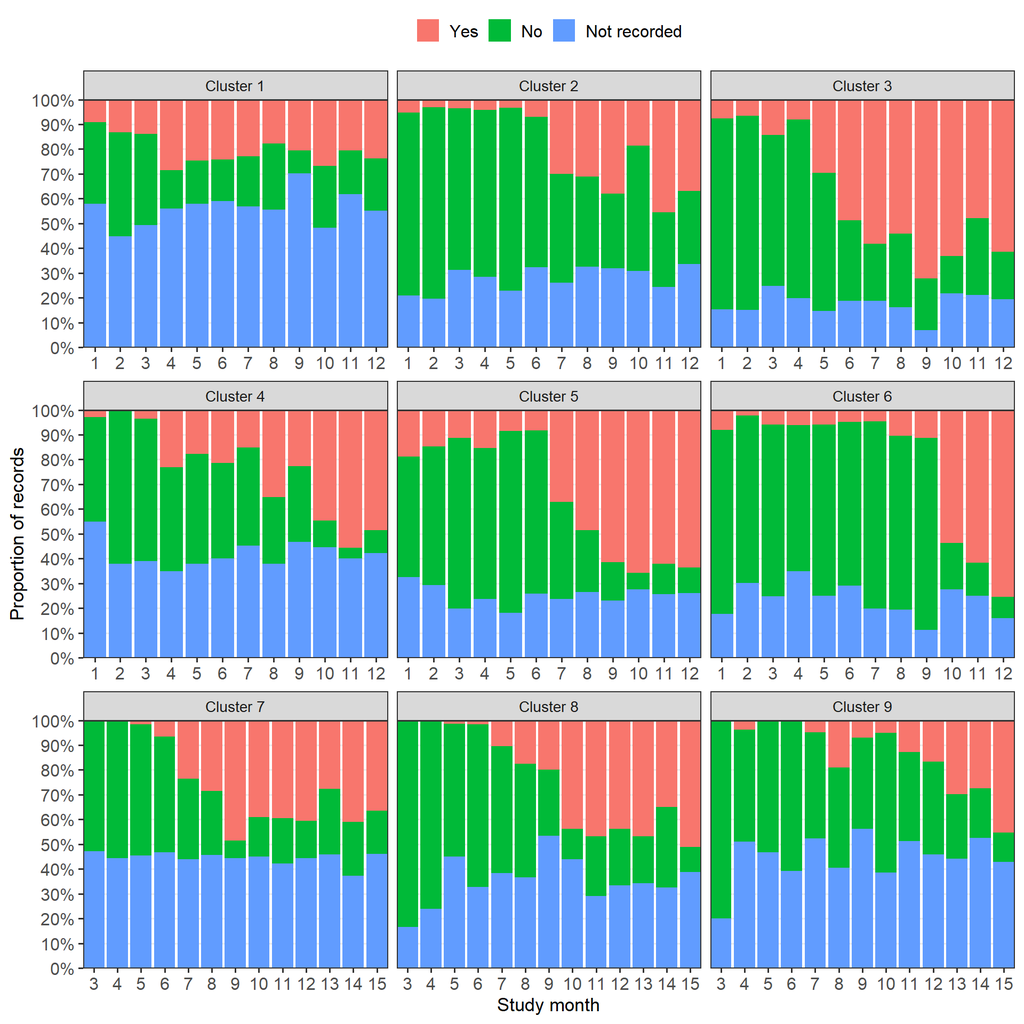

Figure 11: Monthly distribution of oral care on the last day of a patients ward admission

Tables 22 and 23 show descriptive statistics for oral care by control and intervention.

Table 22: Descriptive statistics: oral care performed on the last day

| Study period | n | % |
| --- | --- | --- |
| Control | 473 | 16 |
| Intervention | 1727 | 62 |

Table 23: Descriptive statistics: frequence of oral care on last day

| Study period | Mean (SD) | Median (Q1 to Q3) |
| --- | --- | --- |
| Control | 1.5 (0.8) | 1(1 to 2) |
| Intervention | 1.5 (0.7) | 1(1 to 2) |

Table 24 summarises the percentage of patients with documented oral care on the last day of their admission during control and intervention conditions, after adjusting for clustering. Among patients with documented oral care, the average times performed is also reported. Results are presented as point estimates with 95% confidence intervals.

Table 24: Results of oral care

| Outcome measure | Control | Intervention |
| --- | --- | --- |
| Oral care performed, % | 8; 5.3 to 12 | 42; 32 to 52 |
| Average times oral care performed | 1.4; 1.3 to 1.6 | 1.5; 1.4 to 1.7 |